# DATA 605 FUNDAMENTALS OF COMPUTATIONAL MATHEMATICS

Homework Week 11: Linear Regression

Kyle Gilde

11/11/2017

```
##           installed_and_loaded.packages.
## prettydoc                           TRUE
## dplyr                               TRUE
## ggplot2                             TRUE
## datasets                            TRUE
## gvlma                               TRUE
## MASS                                TRUE
## lmtest                              TRUE
## car                                 TRUE
```

**Using R, build a regression model for data that interests you. Conduct residual analysis. Was the linear model appropriate? Why or why not?**

# Cars Data Set

cars {datasets} R Documentation Speed and Stopping Distances of Cars

Description: The data give the speed of cars and the distances taken to stop. Note that the data were recorded in the 1920s.

Format: A data frame with 50 observations on 2 variables.

[,1] speed numeric Speed (mph) [,2] dist numeric Stopping distance (ft)

Source: Ezekiel, M. (1930) Methods of Correlation Analysis. Wiley.

```r
cars_df <- cars
glimpse(cars_df)
```

```
## Observations: 50
## Variables: 2
## $ speed <dbl> 4, 4, 7, 7, 8, 9, 10, 10, 10, 11, 11, 12, 12, 12, 12, 13...
## $ dist  <dbl> 2, 10, 4, 22, 16, 10, 18, 26, 34, 17, 28, 14, 20, 24, 28...
```

# Question

# Model Summary

```r
cars_model <- lm(dist ~ speed, cars_df)
summary(cars_model)
```

```
##
## Call:
## lm(formula = dist ~ speed, data = cars_df)
##
## Residuals:
##     Min      1Q  Median      3Q     Max
## -29.069  -9.525  -2.272   9.215  43.201
##
## Coefficients:
##             Estimate Std. Error t value Pr(>|t|)
## (Intercept) -17.5791     6.7584  -2.601   0.0123 *
## speed         3.9324     0.4155   9.464 1.49e-12 ***
## ---
## Signif. codes:  0 '***' 0.001 '**' 0.01 '*' 0.05 '.' 0.1 ' ' 1
##
## Residual standard error: 15.38 on 48 degrees of freedom
## Multiple R-squared:  0.6511, Adjusted R-squared:  0.6438
## F-statistic: 89.57 on 1 and 48 DF,  p-value: 1.49e-12
```

```r
intercept <- coef(cars_model)[1]
slope <- coef(cars_model)[2]
```

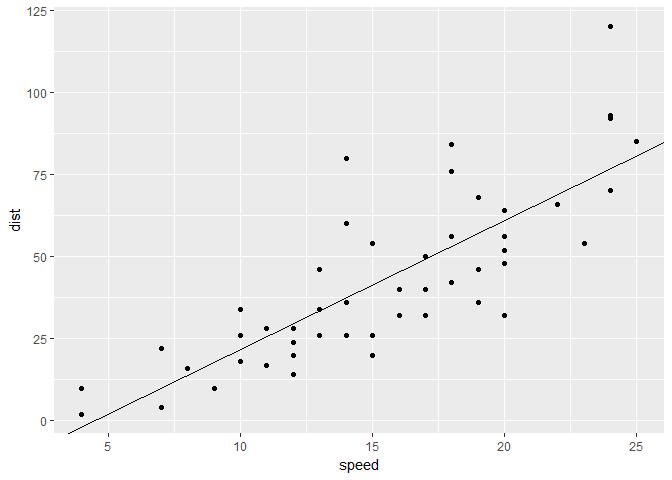

```r
a <- ggplot(cars_model, aes(speed, dist))
a + geom_point() + geom_abline(slope = slope, intercept = intercept, show.legend = TRUE)
```

# Model Interpretation

- This linear model is expressed as $\widehat{StoppingDistance} = -17.5791 + 3.9324*{speed}$
- For each additional increase in the miles per hour, the model expects an increase of 3.9 feet in stopping distance.
- In this model, multiple $R^2$ is 0.6511, which means that the model’s least-squares line accounts for approximately $65\%$ of the variation in the stopping distance.
- The speed’s p-value is near zero and Y-intercept’s p-value is ~1%, which means that there is very little chance that they are not relevant to the model.

# Model Diagnostics

Let’s assess if this linear model is reliable.

## Linearity: Do the variables have a linear relationship?

The Component+Residual plot shows some deviation from a linear relationship.

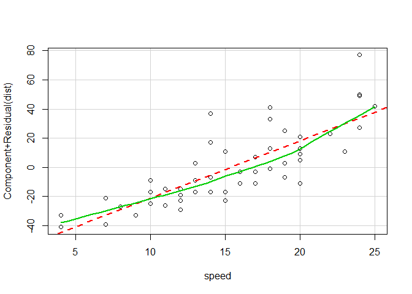

```r
crPlots(cars_model)
```

## Normality: Are the model’s residuals distributed nearly normally?

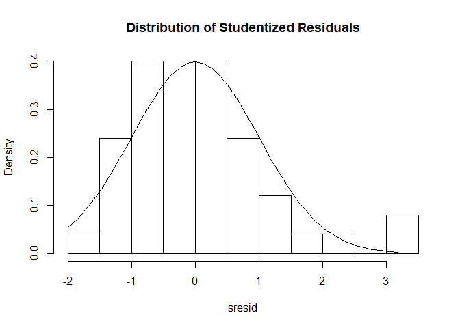

```r
sresid <- studres(cars_model)
hist(sresid, freq = FALSE, breaks = 10, main = "Distribution of Studentized Residuals")
xfit <- seq(min(sresid), max(sresid), length = 40)
yfit <- dnorm(xfit)
lines(xfit, yfit)
```

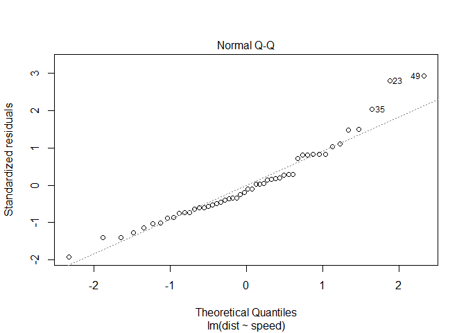

```r
plot(cars_model, which = 2)
```

## Homoscedasticity: Is there constant variability among the residuals?

- Based on the scatter plot, the residuals do show some small deviation in variability.
- The Non-constant Variance Score Test has a p-value of <.05, which means that we reject the null hypothesis of homoscedasticity.

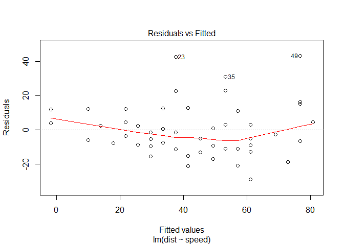

```r
plot(cars_model, which = 1)
```

```r
ncvTest(cars_model)
```

```
## Non-constant Variance Score Test
## Variance formula: ~ fitted.values
## Chisquare = 4.650233    Df = 1     p = 0.03104933
```

## Independence: Are the data from a random sample and not from a time series?

The Durbin Watson test’s p-value is >.05. Therefore, we fail to reject the null hypothesis of independence (no autocorrelation).

```r
durbinWatsonTest(cars_model)
```

```
##  lag Autocorrelation D-W Statistic p-value
##    1       0.1604322      1.676225   0.168
##  Alternative hypothesis: rho != 0
```

# Conclusion

Based upon my diagnostics and the gvlma function, the conditions for linear regression have not been met.

```r
gvlma(cars_model)
```

```
##
## Call:
## lm(formula = dist ~ speed, data = cars_df)
##
## Coefficients:
## (Intercept)        speed
##     -17.579        3.932
##
##
## ASSESSMENT OF THE LINEAR MODEL ASSUMPTIONS
## USING THE GLOBAL TEST ON 4 DEGREES-OF-FREEDOM:
## Level of Significance =  0.05
##
## Call:
##  gvlma(x = cars_model)
##
##                     Value  p-value                   Decision
## Global Stat        15.801 0.003298 Assumptions NOT satisfied!
## Skewness            6.528 0.010621 Assumptions NOT satisfied!
## Kurtosis            1.661 0.197449    Assumptions acceptable.
## Link Function       2.329 0.126998    Assumptions acceptable.
## Heteroscedasticity  5.283 0.021530 Assumptions NOT satisfied!
```

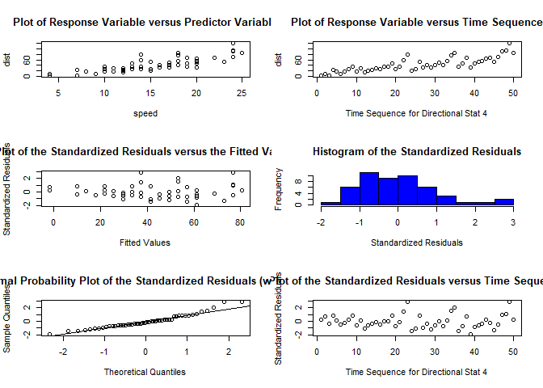

```r
plot(gvlma(cars_model))
```

# References

[Global Validation of Linear Models Assumptions](https://www.rdocumentation.org/packages/gvlma/versions/1.0.0.2)

http://r-statistics.co/Assumptions-of-Linear-Regression.html

https://www.statmethods.net/stats/regression.html

http://ademos.people.uic.edu/Chapter12.html#121_example_2:_a_thanksgiving_not_to_remember,_part_2

http://rstatistics.net/how-to-test-a-regression-model-for-heteroscedasticity-and-if-present-how-to-correct-it/

http://www.statisticshowto.com/durbin-watson-test-coefficient/

http://www.ianruginski.com/regressionassumptionswithR_tutorial.html